# Ecologically informed GWR on modelled avian richness

WM

2026-05-04

## Aim

This notebook evaluates spatial structure and spatial non-stationarity in the modelled avian communities. All response variables are derived from HMSC modelled outputs rather than raw observations:

- predicted richness: summed species occurrence probabilities per grid cell
- predicted community composition: species occurrence probability vectors
- local beta turnover: mean Bray-Curtis dissimilarity from each grid cell to neighbouring grid cells within 200 km

The main GWR analyses now use a fixed 100 km bandwidth. This is the most useful working scale for the current ecological question: local enough to detect sub-regional structure, but less collinearity-prone than the 50 km sensitivity run and less smoothed than the earlier 200 km regional version.

## Build Modelled Response Tables

## Predictor Collinearity

Before deciding whether to use PCA, this section checks local collinearity for the raw environmental predictors at the same fixed bandwidths used in the GWR. The practical read is:

- local VIF below about 5 is usually comfortable
- local VIF above 10 is a stronger warning sign
- local condition number above about 30 suggests unstable local regression

Because the raw land-use predictors stay mostly below these thresholds, the main GWR below uses the raw land-use percentages rather than PCA axes. This makes the driver maps much easier to interpret ecologically.

Interpretation: the raw predictor set is usable at the 100 km working bandwidth, although the 50 km sensitivity run is more collinearity-prone. The practical reason for focusing on 100 km is that it keeps the analysis local while avoiding most of the instability seen at 50 km. PCA is therefore not necessary for the 100 km maps; keeping raw land-use percentages gives more interpretable GWR coefficients.

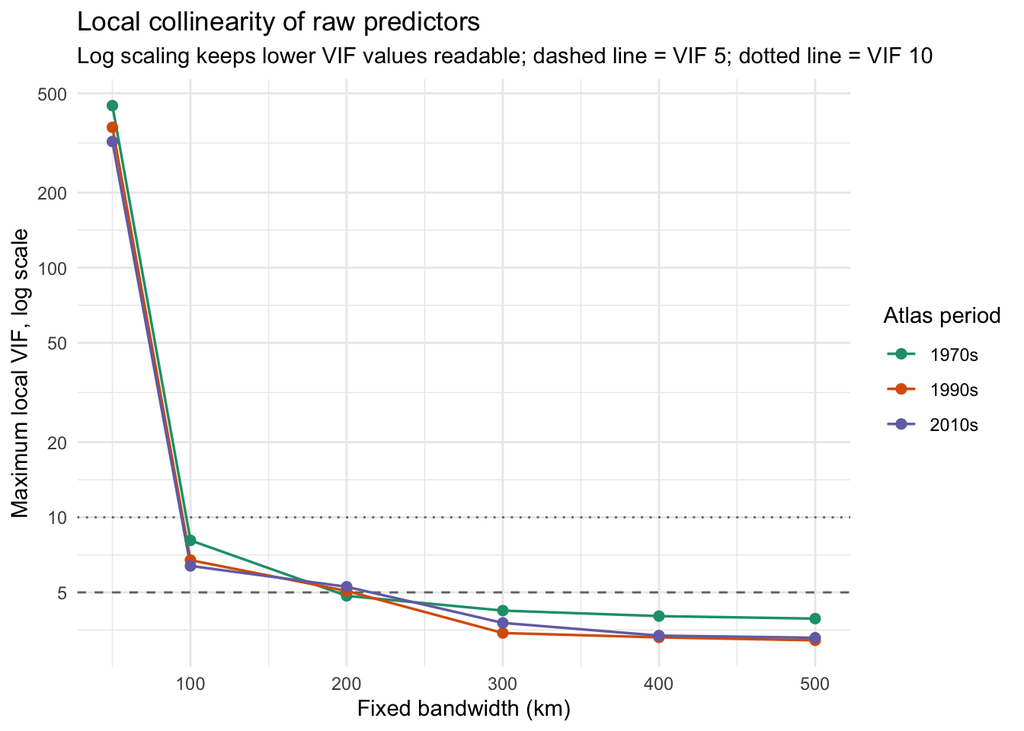

## Spatial Structure in Modelled Richness

These diagnostics ask whether the modelled richness surface is spatially structured before using GWR to interpret local environmental relationships.

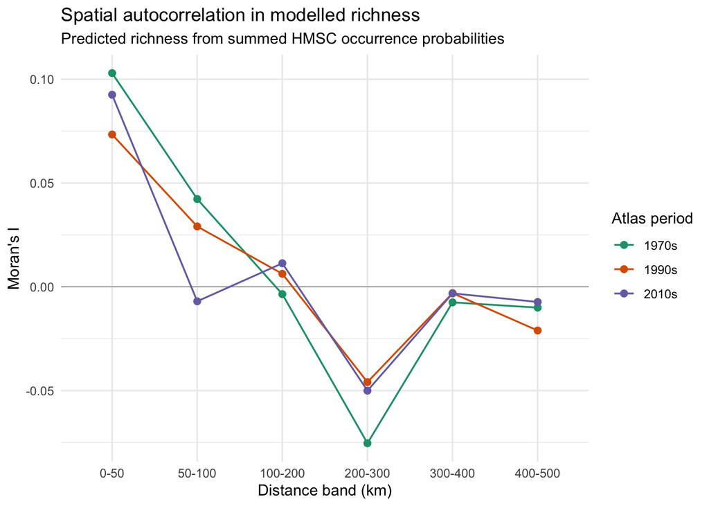

Interpretation: Moran’s I is a correlation-like statistic for spatial clustering in richness. Positive values mean nearby grid cells tend to have similar richness; values near zero mean little spatial clustering at that distance band; negative values mean nearby cells are slightly more dissimilar than expected. The correlogram helps decide whether richness is spatially structured at regional scales before interpreting GWR.

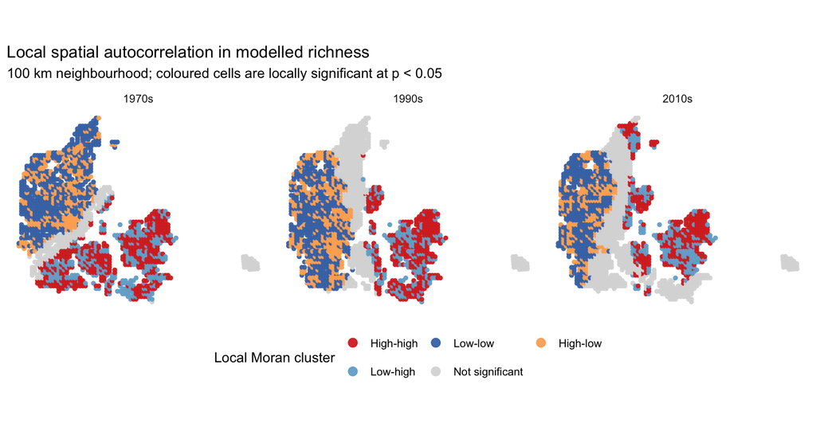

## Spatial Structure in Modelled Community Composition

Here the community data are the predicted species probability vectors. The distance-decay analysis uses Bray-Curtis dissimilarity on probabilities, reported as similarity (`1 - dissimilarity`) by geographic distance band. This asks whether modelled communities are more similar when grid cells are nearby.

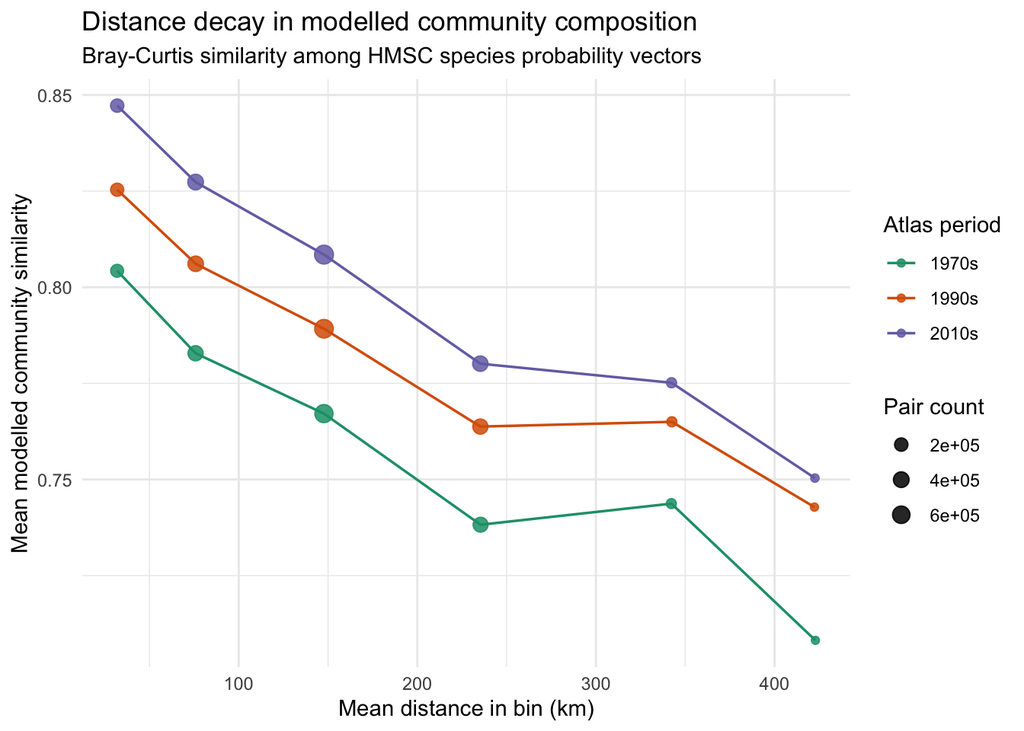

## Local Beta Turnover

The distance-decay plot above is pairwise. For GWR and mapping, we need a site-level turnover response. Here, beta turnover is defined for each grid cell as its mean Bray-Curtis dissimilarity to all neighbouring grid cells within 200 km. High values mean the modelled community in that grid cell is less similar to nearby communities; low values mean it sits in a more homogeneous regional community.

Global Moran’s I for modelled richness and local beta turnover using a 100 km neighbourhood.

| response | period | distance_km | moran_i | expected_i | p_value |
| --- | --- | --- | --- | --- | --- |
| Predicted richness | 1970s | 100 | 0.0634 | -6e-04 | 0 |
| Predicted richness | 1990s | 100 | 0.0447 | -5e-04 | 0 |
| Predicted richness | 2010s | 100 | 0.0288 | -5e-04 | 0 |
| Local beta turnover | 1970s | 100 | 0.0239 | -6e-04 | 0 |
| Local beta turnover | 1990s | 100 | 0.0340 | -5e-04 | 0 |
| Local beta turnover | 2010s | 100 | 0.0227 | -5e-04 | 0 |

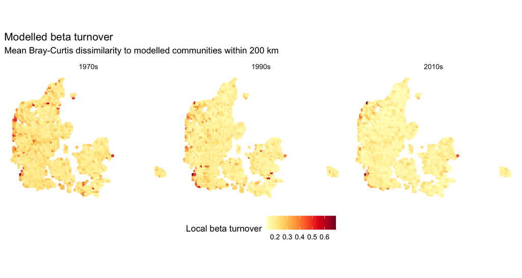

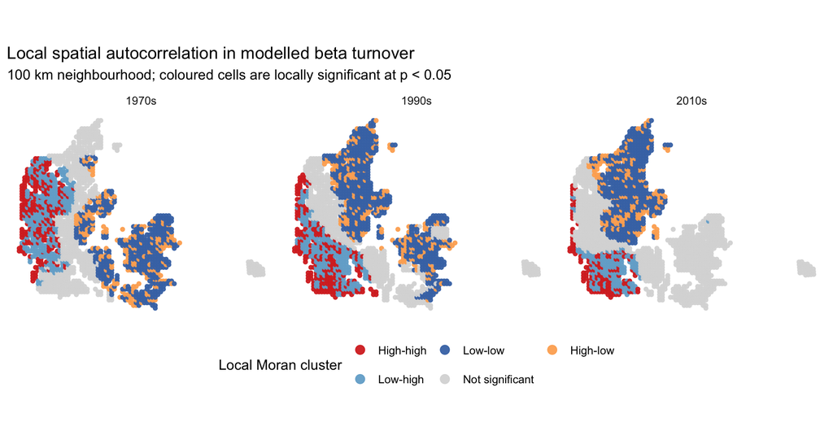

Interpretation: the beta-turnover map identifies where modelled communities are compositionally unusual relative to nearby cells. The local Moran map then asks whether those high- or low-turnover areas form spatial clusters. This is closer to the ecological question of whether community differences themselves are spatially structured.

## 100 km GWR Models

The regression maps below use a fixed 100 km bandwidth. The fixed bandwidth is in metres because the grid coordinates are projected coordinates. Earlier sensitivity runs at 50 and 200 km are retained on disk, but the readable report now centres on 100 km.

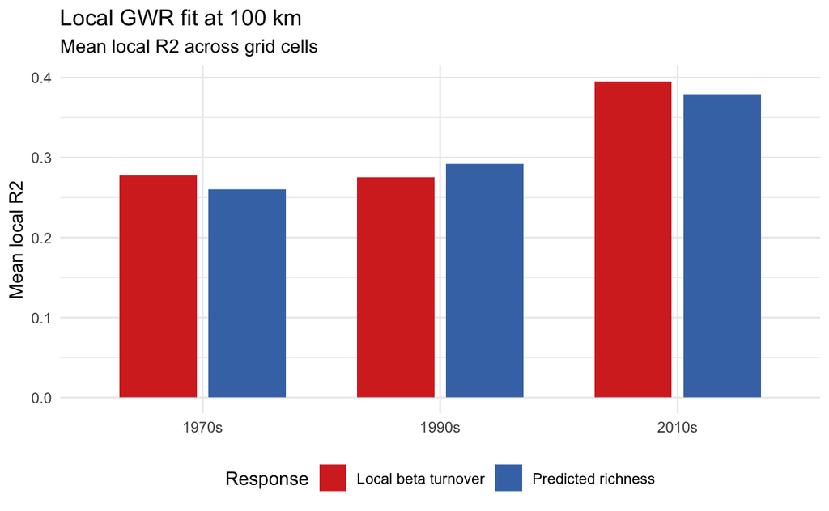

Interpretation: local R2 shows how much of the response is explained locally by the environmental predictors. Higher values mean the 100 km local regression is capturing more of the spatial variation in that response.

## Focal 100 km GWR Maps

The maps below show the dominant local driver at each grid cell. “Dominant” here means the predictor with the largest absolute local t-value. A cell is coloured only when that largest local t-value exceeds `|1.96|`; otherwise it is labelled as no significant driver. Shape gives the sign of the relationship.

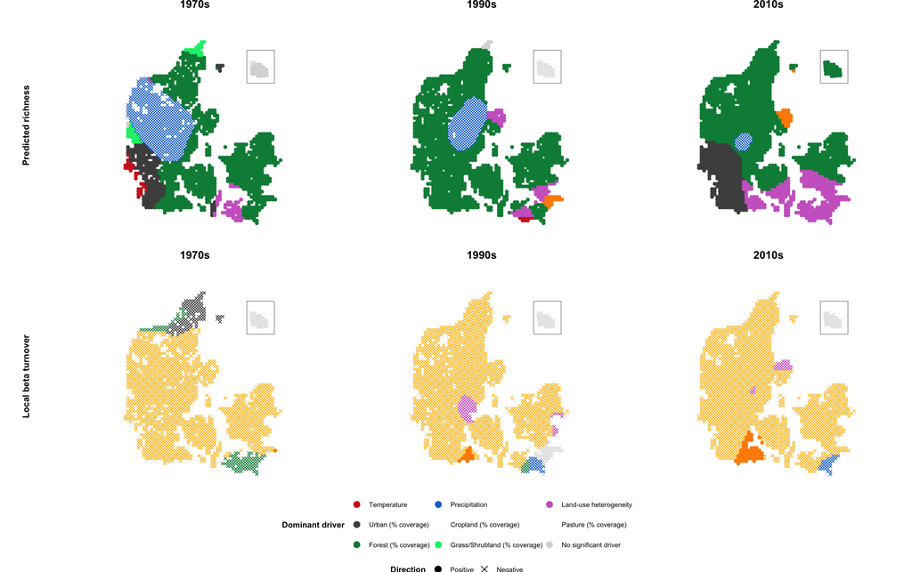

Interpretation: the richness GWR asks which environmental variables explain spatial variation in the number of modelled species. The beta-turnover GWR asks which environmental variables explain where modelled community composition changes most strongly relative to nearby grid cells. These are related but not equivalent: richness can be spatially smooth while composition turns over. The Bornholm inset uses the same symbols and colours as the mainland panels, so it can be read directly as part of the same 100 km analysis.

## Avian Bioregion And Beta-PCA Analyses

The modelled avian bioregion shift analysis and the species-level environmental beta-parameter PCA now live in the focused companion notebook `notebooks/exploratory/z-avian-bioregion-pca.Rmd`. This keeps the present notebook focused on richness, beta turnover, spatial autocorrelation, and 100 km GWR.